# Multiview Composition and Information Density

Author

Kris Sankaran

Published

September 1, 2026

Readings: [1](https://clauswilke.com/dataviz/multi-panel-figures.html), [2](https://www.edwardtufte.com/notebook/sparkline-theory-and-practice-edward-tufte/) (optional), [3](https://medium.com/@hint_fm/design-and-redesign-4ab77206cf9) (optional)

Items marked with $^\dagger$ will not be tested on exams.

## Concepts

1. It might seem like we’re limited with the total number of variables we can display at a time. While there are many types of encodings we could in theory use, only a few them are very effective, and they can interfere with one another.
2. There are several ways around this, though. One of the most effective is to combine multiple views, either in parallel (small multiples) or which complement one another (multiform views). We’ll study why this works and the design considerations that make the results more readable.

### Small Multiples

3. Our eyes are good at making sense of many small plots, as long as there is shared structure across the plots. We can quickly scan the collection and spot meaningful relationships. Formally, a small multiples plot first partitions the data into disjoint subsets and then applies the same encoding to each of the subsets. Each subset is associated with a small panel within the larger plot.
4. Some important considerations are,
   - Should the views share the same axes? Sharing makes panels directly comparable, but if the data ranges are very different, it might be difficult to read differences within some of the panels.
   - How should the panels be arranged? If the subsets are determined by a categorical variable, we could always use sort alphabetically to help with direct lookups. Alternatively, we could sort by some property of the data within each panel (e.g., average $y$-axis value).

   The basic downside of this approach is that it takes up a lot of space, since we are repeating an base visualization many times. When there are many subsets, we either have to shrink the individual panels (which can become illegible) or make the visualization very large (which we may not want to do if it’s not the most important message to communicate).
5. Here’s a historical example, by Francis Walker for the 1870 US Census. Note the simplicity of each component, which keeps the overall display readable.

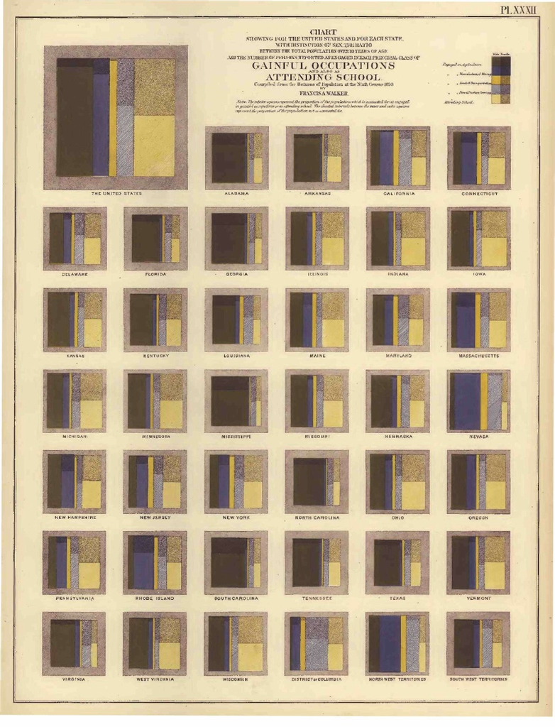

6. Keep these kinds of plots in mind as a potential alternative to interactivity. When we cover interactive visualization, we will show how to use user-controlled inputs to filter down to different subsets and update the visual display accordingly. This serves a similar purpose as small multiples, and doesn’t have the problem of taking up so much space as small multiple plots. However, interactivity has the downside of creating a large memory burden (the same problem applies to animation). We have remember what the previous subset looked like, while with small multiples we can make the comparison directly. Here’s a famous historical example to highlight the benefit of small multiples in reducing memory burden, from Muybridge.

[figure not shown]

7. Ridge plots are a special case of small multiples that are particularly suited to displaying multiple parallel time series or densities. An example ridge plot for the gapminder dataset is shown below. The effectiveness of this plot comes from the fact that multiple densities can be displayed in close proximity to one another, making it possible to facet across many variables in a space-efficient way.

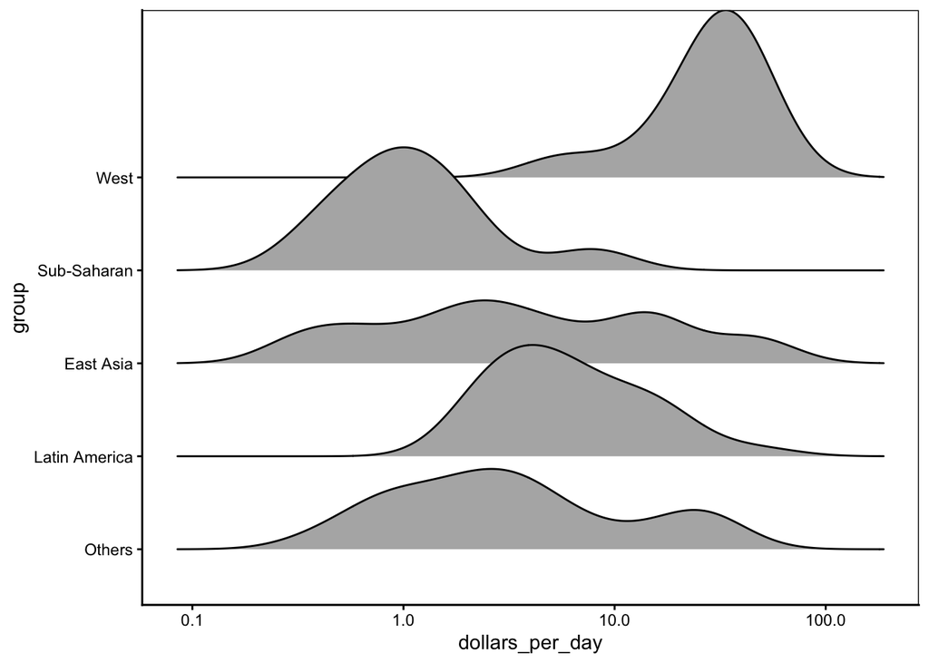

8. Why not plot the raw data? We do this using a `geom_point` below. The result isn’t as satisfying, because, while the shape of the ridges popped out immediately in the original plot, we have to invest a bit more effort to understand the regions of higher density in the raw data plot. Also, when there are many samples, the entire range might appeared covered in marks when in fact there are some intervals with higher density than others.

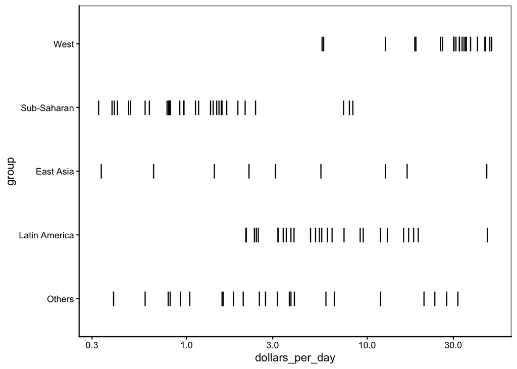

A nice compromise is to include both the raw positions and the smoothed densities.

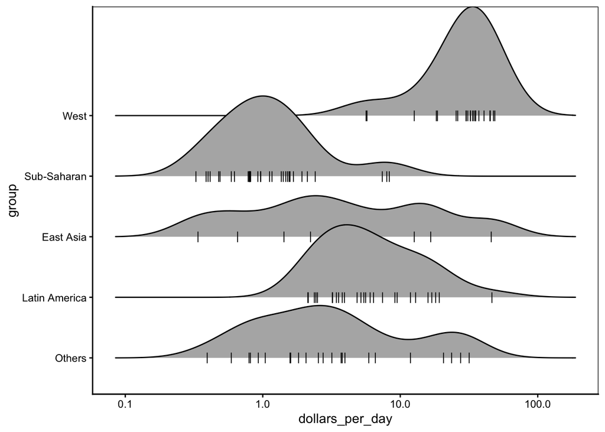

9. Another special case are sparklines. These are small, simplified line plots that are integrated directly into text.

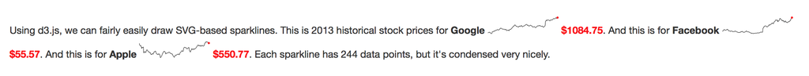

They show trends without any axes or labels, which keeps them from feeling too cluttered. At most, selective annotation can be used highlight a few points of interest.

10. Besides direct integration into text, it’s common to see sparklines in merged into standalone figures. Even though there are many plots, the fact that they all share the same encoding means our eyes quickly recognize groupings and exceptions.

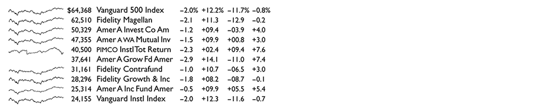

### Multiform Plots

11. Small multiples are useful whenever we want different rows of the data to appear in different panels. What if we want to compare different columns, or work with several datasets? An alternative is to use multiform plots. The idea is to construct plots separately and then combine them only at the very end. This can be understood as the opposite of small multiples: Instead of applying the same encoding to different data subsets, we show different encodings of the same data.
12. The main advantage of multiform plots is that individual panels can be tailored to specific visual comparisons, but relationships across panels can also be studied. For example, the plot below shows change in the total number and composition of undergraduate majors over the last few decades. In principle, the same information could be communicated using a stacked area plot. However, comparing the percentages for 1970 and 2015 is much more straightforward using a line plot, and we can still see changes in the overall number of degrees using the area plot.

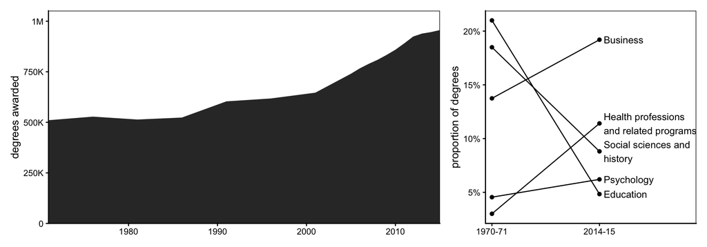

For reference, here is a non-multiform display of the same information.

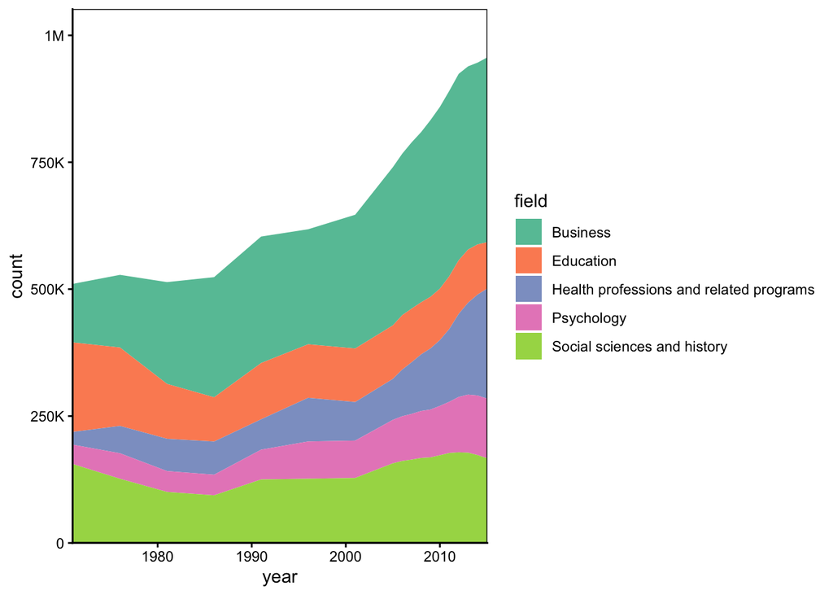

13. There are a few considerations that can substantially improve the quality of a multiform plot,
    - Consistent visual encodings for shared variables
    - Clear, but unobtrusive annotation
    - Proper alignment in figure baselines

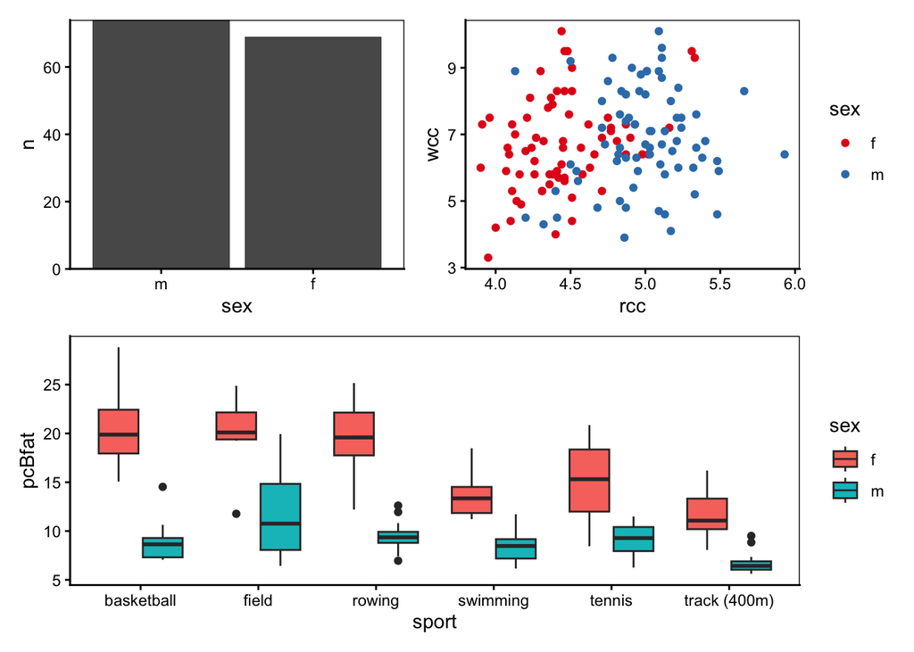

[output not shown]

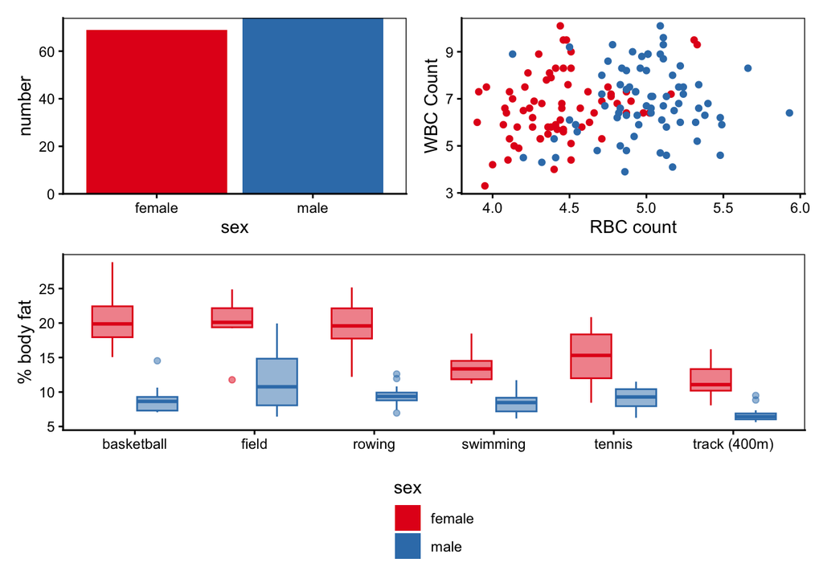

15. Effective annotation can be used to refer to different subpanels of the data without drawing too much attention to itself. Labels should be visible but subtle – not too large, similar fonts as the figures, and logically ordered ((a) on top left). A nice heuristic is to think of these annotations like page numbers. They are useful for making references, but aren’t something that is actively read.

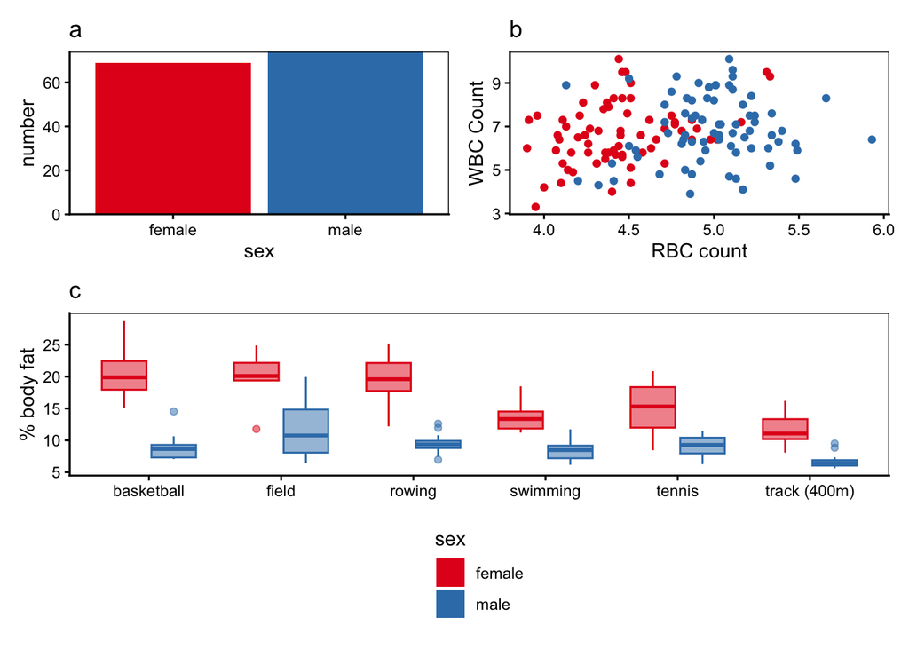

1. For alignment, we will want figure baselines / borders to be consistent. Misalignment can be distracting. This is primarily a problem when multiform plots are made from manually. If we follow the programmatic approaches discussed in the next lecture, we won’t have this issue.

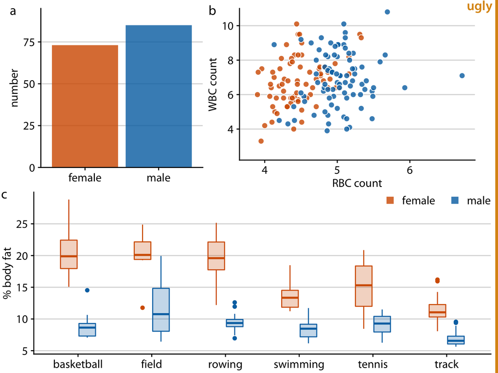

### Information Density

16. Small multiples (and especially sparklines) are most legible when they trim away extraneous marks, allowing us to focus on the data itself. This principle applies to other figures and has been called *information density* or the *data-to-ink ratio*. We can increase information density by trimming away grid lines, reducing the number of digits in axes labels, removing borders from legends, etc.
17. A startling example is this redesign of a visualization related to the Space Shuttle Challenger disaster, which was caused by damage to the shuttle’s O-rings due to unusually cold weather. Here is a version from the official investigation into the disaster.

[figure not shown]

Edward Tufte redesigned the figure to increase the data-to-ink ratio,

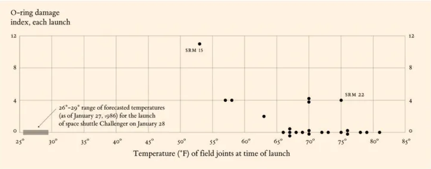

which makes the relationship between temperature and O-ring damage much clearer. Tufte argues that had these clearer visualization designs been part of standard practice at NASA, then the disaster might have been prevented. We should take this with a grain of salt, though. [viegaswattenberg] point out that the safety of the launch could be affected by many components of the shuttle, each of which could be damaged by environmental or engineering factors. We only know to plot temperature against O-ring damage after the disaster already happened.

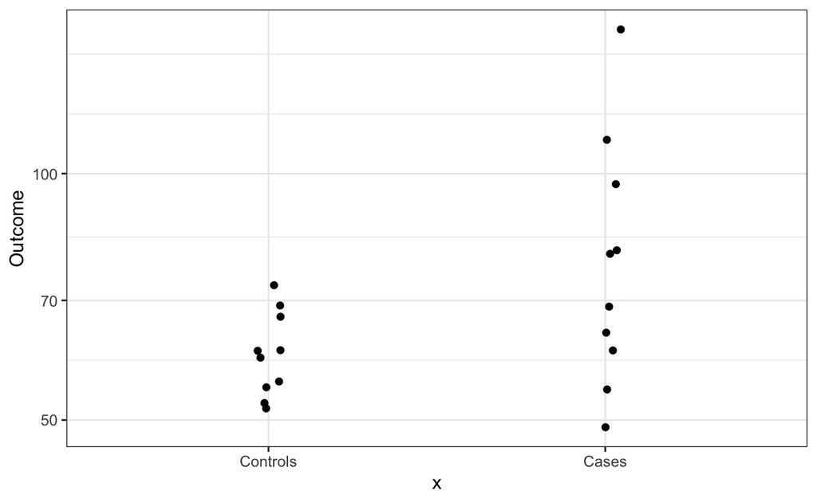

If summaries are essential for making comparisons, then we could alternatively superimpose them over the raw data [irizzary] using a boxplot or ridgeplot.

[figure not shown]

## Implementation

### `ggplot2`

19. There are two ggplot2 layers for making small multiples, which the package calls “facets”. The first, `facet_grid` uses formula syntax to split the data into subsets, each of which is associated with a panel. For example, `~ island` splits the three islands into columns.

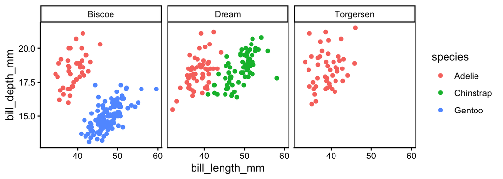

```r
ggplot(penguins, aes(bill_length_mm, bill_depth_mm, color = species)) +
    geom_point() +
    facet_grid(~ island)
```

Placing the variable before the `~` splits across rows.

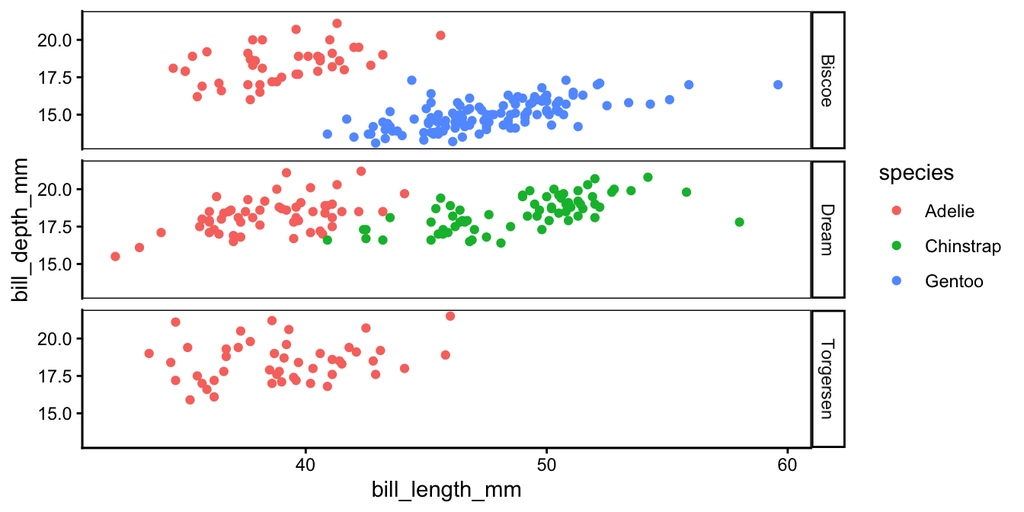

```r
ggplot(penguins, aes(bill_length_mm, bill_depth_mm, color = species)) +
    geom_point() +
    facet_grid(island ~ .)
```

We can facet across multiple variables. Variables before `~` are split across rows, those afterwards are split across columns.

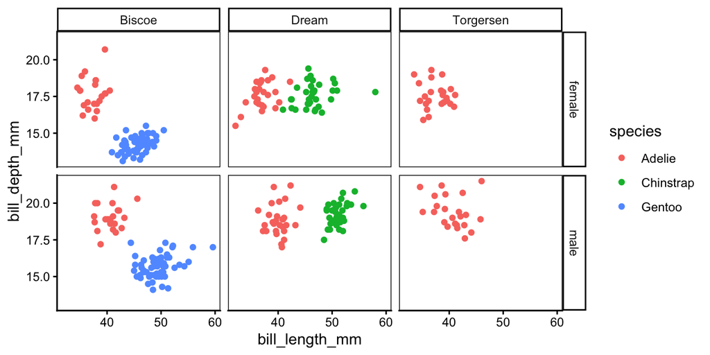

```r
ggplot(penguins, aes(bill_length_mm, bill_depth_mm, color = species)) +
    geom_point() +
    facet_grid(sex ~ island)
```

Exercise: How might we facet with a continuous variable? Hint: Consider `cut()`.

Exercise: What about more complicated formulas? Try `sex + island ~ year`

20. If we have many very many panels and don’t want them all in one row, we can use `facet_wrap`. It enforces a maximum number of panels per row and wraps extra panels onto new rows.

```r
ggplot(penguins, aes(bill_length_mm, bill_depth_mm, color = species)) +
  geom_point() +
  facet_wrap(~island)
```

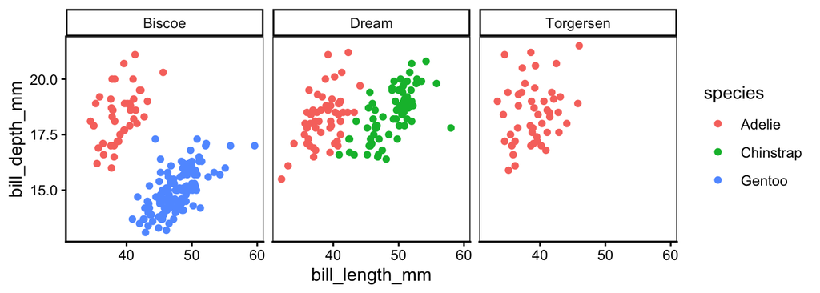

21. By default, the panels are sorted alphabetically. But to increase information density, it helps to instead sort by a property of the data. We can use `reorder` within our formula to sort the categories by a variable of interest.

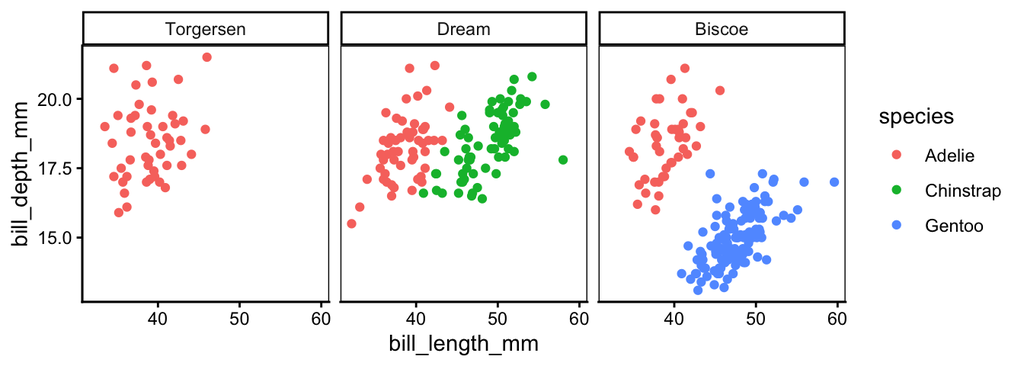

```r
ggplot(penguins, aes(bill_length_mm, bill_depth_mm, color = species)) +
  geom_point() +
  facet_wrap(~reorder(island, bill_length_mm))
```

Exercise: By default `reorder` sorts using the mean of the second argument within each group of the first. It’s possible to sort by other properties, like median or variance. How is this done?

### `ggridges`

22. The ggridges package can be used to create ridge plots. If we want to organize many densities according to a ridge plot, we can use `geom_density_ridges`.

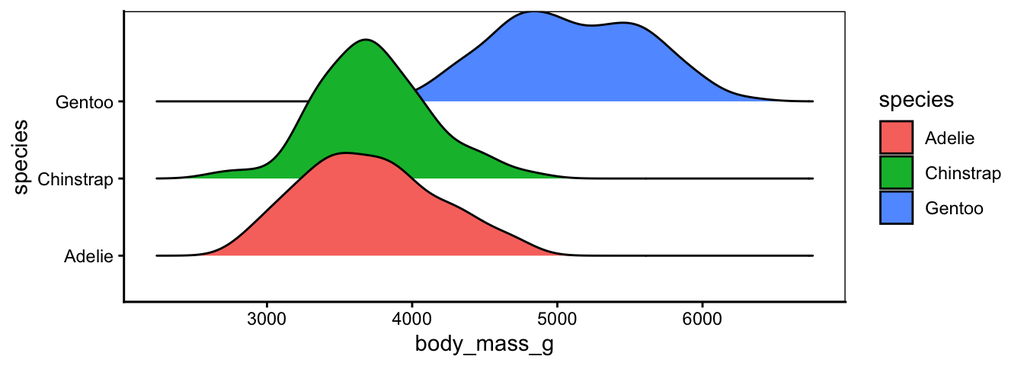

```r
ggplot(penguins, aes(body_mass_g, species, fill = species)) +
  geom_density_ridges()
```

23. Sometimes we want a ridge plot and already have the height values for the ridges computed in advance. In this case, we can use `geom_ridgeline` with a height encoding.

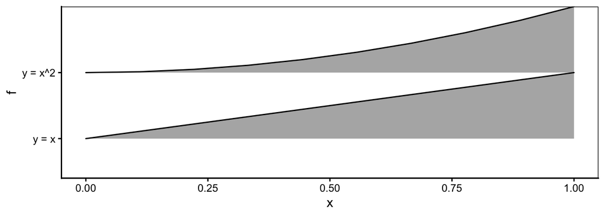

```r
tibble(x = seq(0, 1, length.out = 10)) |>
    mutate(
       `y = x` = x,
       `y = x^2` = x^2
    ) |>
    pivot_longer(-x, names_to = "f", values_to = "y") |>
    ggplot(aes(x, f, height = y)) +
    geom_ridgeline()
```

### `patchwork`

24. `patchwork` can be used to merge ggplot2 components into multiform plots. It uses `a + b` to places ggplot objects `a` and `b` side-by-side and `/` to place them vertically. The `plot_layout` command can be used to customize the theme of the overall plot, for example, setting `guides = "collect"` ensures all legends are taken out of the component plots and gathered in a single place. We can also use the `widths` and `heights` argument of this function to control the relative size of the components.

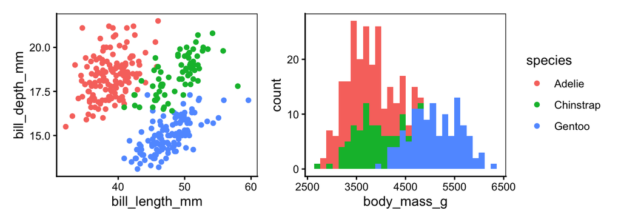

```r
p1 <- ggplot(penguins, aes(bill_length_mm, bill_depth_mm, color = species)) +
  geom_point()

p2 <- ggplot(penguins, aes(body_mass_g, fill = species)) +
  geom_histogram(bins = 30) +
  scale_fill_discrete(guide = "none")

p1 + p2 +
  plot_layout(guides = "collect")
```

*Exercise: We removed the color legend for the histogram `p2` using `guide = "none"` in the `scale_fill_discrete` layer. Why? What would have happened to the plot if we removed this layer?*

25. We can use `+` and `/` like algebraic symbols to compose more complex layouts. For example, below we place two plots side-by-side and both of those on top of a third.

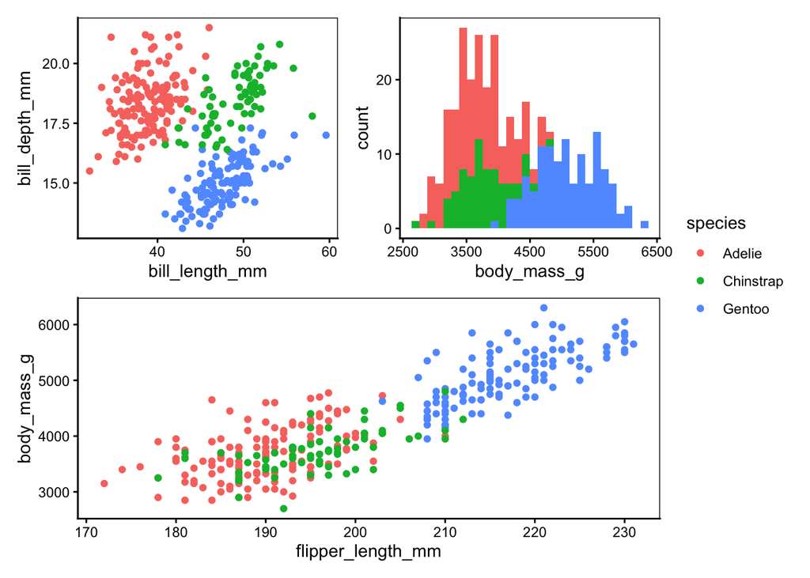

```r
p3 <- ggplot(penguins, aes(flipper_length_mm, body_mass_g, color = species)) +
  geom_point()

(p1 + p2) / p3 +
  plot_layout(guides = "collect")
```

### vgplot concat

26. Let’s first read in the penguins dataset. We use a locally saved, preprocessed copy so that missing values do not cause numeric columns to be read as strings.

```javascript
path = (p) => new URL(`data/${p}`, document.baseURI).href

vg = {
  const mod = await import("https://cdn.jsdelivr.net/npm/@uwdata/vgplot@0.19.0/+esm");
  const wasm = await mod.wasmConnector();
  mod.coordinator().databaseConnector(wasm);
  return mod;
}

// load the penguins data
penguins_db = {
  await vg.coordinator().exec([
    vg.loadCSV("penguins", path("penguins.csv"), { header: true })
  ]);
  return true;
}
```

[interactive chart not shown]

27. `vgplot` doesn’t support faceting directly, but you can compose component plots using `hconcat` and `vconcat`, analogous to patchwork’s `+` and `/`. This can be used to manually create faceted plots, but the subsets and component plots have to be created manualy.

```javascript
{
  await penguins_db;

    // define two component plots
    const scatterPlot = vg.plot(
        vg.dot(
            vg.from("penguins"),
            {x: "bill_length_mm", y: "bill_depth_mm", fill: "species"}
        ),
        vg.width(300),
        vg.height(250)
    );

    const barChart = vg.plot(
        vg.rectY(
            vg.from("penguins"),
            {x: vg.bin("body_mass_g"), y: vg.count(), fill: "species"}
        ),
        vg.width(300),
        vg.height(250)
    );

    // combine with hconcat
    return vg.hconcat(scatterPlot, barChart);
}
```

[interactive chart not shown]

### Objectives

By the end of this week, you should be able to,

- Compare and contrast faceting with multiform visualizations.
- Critique and suggest improvements to a visualization from the information density perspective.
- Describe best practices for ensuring readability of multiform plots.
- Given examples of ggplot2 faceting or mosaic concatenation code, describe what each element means and what the output would look like.
- Given examples of patchwork code, describe what the syntax means and what the output would look like.